# Gettting Started with R

# Insatllation of R

### Step 1- Go to your Beowser and search “r-project.org” and open the firdt link . A webpag will appear

[figure not shown]

### Step 2- Click on download R and then select the download link under 0-cloud

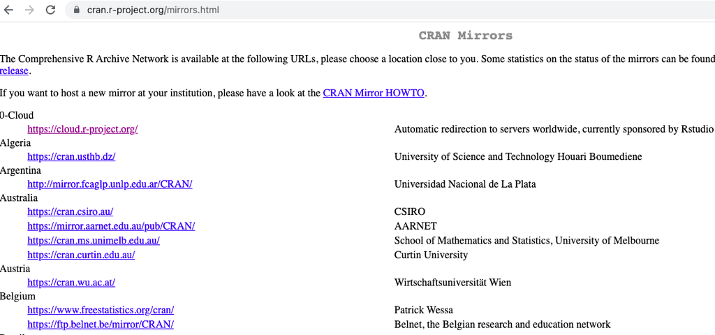

### Step 3- Select Download link which is suitable for your computer and select suitable version of R and start downloading

[figure not shown]

### Step 4- once Download is complete, click Install and follow the steps given

[figure not shown]

**Click Continue**

[figure not shown]

**Click Continue**

[figure not shown]

**Select Agree**

[figure not shown]

**Click Install**

[figure not shown]

**installation is completed**

### Step 5- Once Installation is successfully completed, Open R in your Computer, You will see a basic console window where you can run R code

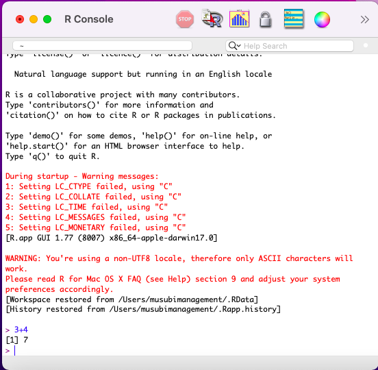

console page

# Installing R Studio

Sometimes its very difficult to code R in R_console specially when we perform multiple operations at once. For better Experience we use an IDE for R language called R Studio

Below is the Step by Step procedure to Install R studio

### Step 1- Open your web Browser and type download R studio and open the first link “https://www.rstudio.com/products/rstudio/download/”

[figure not shown]

**download page page**

### Step 2- Click on R- Studio Desktop Download Button ( Free version). and select the suitable version for your computer and start Downloading

[figure not shown]

**select required download suitable for your computer**

### Step 3- Complete the installation Process and open R Studio

[figure not shown]

**R Studio workplace**